# Model Comparison Part II: Random Regressions

Hadasch, Schmidt, Piepho

05 Februar 2018

# General Information

- Dataset = aman
- Mod1:
  - $\begin{aligned} var(GL) &= \sigma_{GL}^2 \\ var(GY) &= \sigma_{GY}^2 \\ var(GYL) &= \sigma_{GYL}^2 + \sqrt{r_i}\sigma_{GYL}^2 + \sqrt{t_j}\sigma_{GYL}^2 \end{aligned}$
- Mod2:
  - $\begin{aligned} var(GL) &= \sigma_{GL}^2 \\ var(GY) &= \sigma_{GY}^2 \\ var(GYL) &= \sigma_{GYL}^2 + \sqrt{r_i}\sigma_{GYL}^2 + r_i \sigma_{GYL}^2 + \sqrt{t_j}\sigma_{GYL}^2 + t_j \sigma_{GYL}^2 \end{aligned}$
- Mod3:
  - $\begin{aligned} var(GL) &= \sigma_{GL}^2 + \sqrt{r_i}\sigma_{GL}^2 \\ var(GY) &= \sigma_{GY}^2 + \sqrt{r_i}\sigma_{GY}^2 + \sqrt{t_j}\sigma_{GY}^2 \\ var(GYL) &= \sigma_{GYL}^2 + \sqrt{r_i}\sigma_{GYL}^2 + \sqrt{t_j}\sigma_{GYL}^2 \end{aligned}$
- Mod4:
  - $\begin{aligned} var(GL) &= \sigma_{GL}^2 + \sqrt{r_i}\sigma_{GL}^2 + r_i \sigma_{GL}^2 \\ var(GY) &= \sigma_{GY}^2 + \sqrt{r_i}\sigma_{GY}^2 + r_i \sigma_{GY}^2 + \sqrt{t_j}\sigma_{GY}^2 + t_j \sigma_{GY}^2 \\ var(GYL) &= \sigma_{GYL}^2 + \sqrt{r_i}\sigma_{GYL}^2 + r_i \sigma_{GYL}^2 + \sqrt{t_j}\sigma_{GYL}^2 + t_j \sigma_{GYL}^2 \end{aligned}$
- Model Outputs (further formatting not shown):
  - AIC: `-2*MODELOBJECT$loglik + 2*length(MODELOBJECT$gammas)`
  - Wald test: `wald(MODELOBJECT, denDF = c("none"),ssType = c("incremental","conditional"))`
  - Variance Components: `summary(MODELOBJECT)$varcomp`
  - Residual Plot per $t_j$: `plot(dat3$tj,residuals(MODELOBJECT, type=("pearson")))`

### Create variables from ri and tj

```r
# "Centered" and squareroot
dat3$sc_ri <- sqrt(dat3$ri - min(dat3$ri)+1)
dat3$sc_tj <- sqrt(dat3$tj - min(dat3$tj)+1)
# "Centered"
dat3$c_ri  <- dat3$ri - min(dat3$ri)+1
dat3$c_tj  <- dat3$tj - min(dat3$tj)+1

# Display "centered" c_tj levels
unique(dat3$c_tj)
```

```
##  [1]  1  2  3  4  5  6  7  8  9 10 11 12 13 14 15
```

## Model 1

```r
Mod1 <- asreml(fixed   = adjmean ~ ri + tj,
                 random  = ~ G + L + Y + G:L + G:Y +
                             G:Env +
                             sc_tj:G:Env +
                             sc_ri:G:Env,
                 ran.order = "user",
                 G.param = Gpar,
                 weights = w,
                 family  = asreml.gaussian(dispersion=1.0),
                 control = asreml.control(pworkspace=8e10,workspace=8e8,maxiter=100),
                 data    = dat3)
```

```
## [1] 1966.849
```

```
##                              component   std.error    constraint
## G!G.var                0.3036106313250 0.087031987      Positive
## L!L.var                0.2771515498546 0.140580698      Positive
## Y!Y.var                0.1064523026652 0.043837404      Positive
## G:L!G.var              0.0216993310895 0.009992355      Positive
## G:Y!G.var              0.0000001011929          NA      Boundary
## G:Env!G.var            0.9796092184305 0.068763932      Positive
## sc_tj:G:Env!sc_tj.var -0.0175324129598 0.006096274 Unconstrained
## sc_ri:G:Env!sc_ri.var -0.0046128554846 0.002141190 Unconstrained
## R!variance             1.0000000000000          NA         Fixed
```

```
##               Df Wald statistic Pr(Chisq)
## (Intercept)    1        313.873    <2e-16 ***
## ri             1          0.022    0.8822
## tj             1          0.500    0.4794
## residual (MS)
## ---
## Signif. codes:  0 '***' 0.001 '**' 0.01 '*' 0.05 '.' 0.1 ' ' 1
```

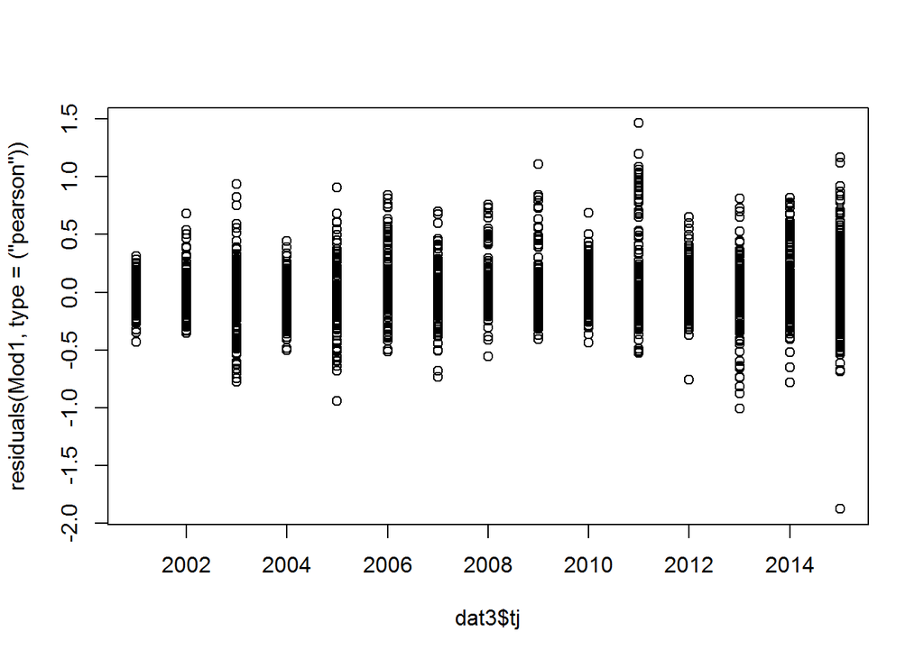

## Model 2

```r
Mod2 <- asreml(fixed   = adjmean ~ ri + tj,
                 random  = ~ G + L + Y + G:L + G:Y +
                                   G:Env +
                             sc_tj:G:Env + c_tj:G:Env +
                             sc_ri:G:Env + c_ri:G:Env,
                 ran.order = "user",
                 G.param = Gpar,
                 weights = w,
                 family  = asreml.gaussian(dispersion=1.0),
                 control = asreml.control(pworkspace=8e10,workspace=8e8,maxiter=100),
                 data    = dat3)
```

```r
-2* Mod2$loglik + 2*length(Mod2$gammas) # AIC
```

```
## [1] 2052.87
```

```
##                             component    std.error constraint
## G!G.var                0.309872198324 0.0948552566   Positive
## L!L.var                0.273488136916 0.1446555411   Positive
## Y!Y.var                0.106706378774 0.0451065743   Positive
## G:L!G.var              0.021199790355 0.0133343613   Positive
## G:Y!G.var              0.000000100245           NA   Boundary
## G:Env!G.var            0.924221340855 0.1662551783   Positive
## sc_tj:G:Env!sc_tj.var  0.000034629105 0.0375891351   Boundary
## c_tj:G:Env!c_tj.var   -0.000771792641 0.0021674552   Boundary
## sc_ri:G:Env!sc_ri.var -0.000008448056 0.0109234509   Boundary
## c_ri:G:Env!c_ri.var    0.000003167702 0.0002782923   Boundary
## R!variance             1.000000000000           NA      Fixed
```

```
##               Df Wald statistic Pr(Chisq)
## (Intercept)    1        308.664    <2e-16 ***
## ri             1          0.028    0.8678
## tj             1          0.593    0.4414
## residual (MS)
## ---
## Signif. codes:  0 '***' 0.001 '**' 0.01 '*' 0.05 '.' 0.1 ' ' 1
```

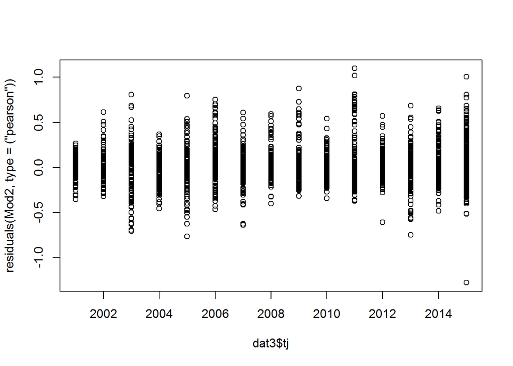

## Model 3

```r
Mod3 <- asreml(fixed   = adjmean ~ ri + tj,
                 random  = ~ G + L + Y +
                           G:L   + sc_ri:G:L   +
                           G:Y   + sc_ri:G:Y   + sc_tj:G:Y   +
                           G:Env + sc_ri:G:Env + sc_tj:G:Env,
                 ran.order = "user",
                 G.param = Gpar,
                 weights = w,
                 family  = asreml.gaussian(dispersion=1.0),
                 control = asreml.control(pworkspace=8e10,workspace=8e8,maxiter=100),
                 data    = dat3)
```

```r
-2* Mod3$loglik + 2*length(Mod3$gammas) # AIC
```

```
## [1] 1955.515
```

```
##                              component    std.error    constraint
## G!G.var                0.3131415935715 0.0883319489      Positive
## L!L.var                0.2735102001467 0.1388075431      Positive
## Y!Y.var                0.1084629203230 0.0441590583      Positive
## G:L!G.var              0.0061677855938 0.0202897334      Positive
## sc_ri:G:L!sc_ri.var    0.0006829174391 0.0009483978 Unconstrained
## G:Y!G.var              0.0000001011929           NA      Boundary
## sc_ri:G:Y!sc_ri.var   -0.0008818142704 0.0006653470 Unconstrained
## sc_tj:G:Y!sc_tj.var   -0.0008950086932 0.0016684639 Unconstrained
## G:Env!G.var            0.9450121524925 0.0681989076      Positive
## sc_ri:G:Env!sc_ri.var -0.0036740304727 0.0023649783 Unconstrained
## sc_tj:G:Env!sc_tj.var -0.0134737912259 0.0063950759 Unconstrained
## R!variance             1.0000000000000           NA         Fixed
```

```
##               Df Wald statistic Pr(Chisq)
## (Intercept)    1        314.235    <2e-16 ***
## ri             1          0.012    0.9110
## tj             1          0.448    0.5033
## residual (MS)
## ---
## Signif. codes:  0 '***' 0.001 '**' 0.01 '*' 0.05 '.' 0.1 ' ' 1
```

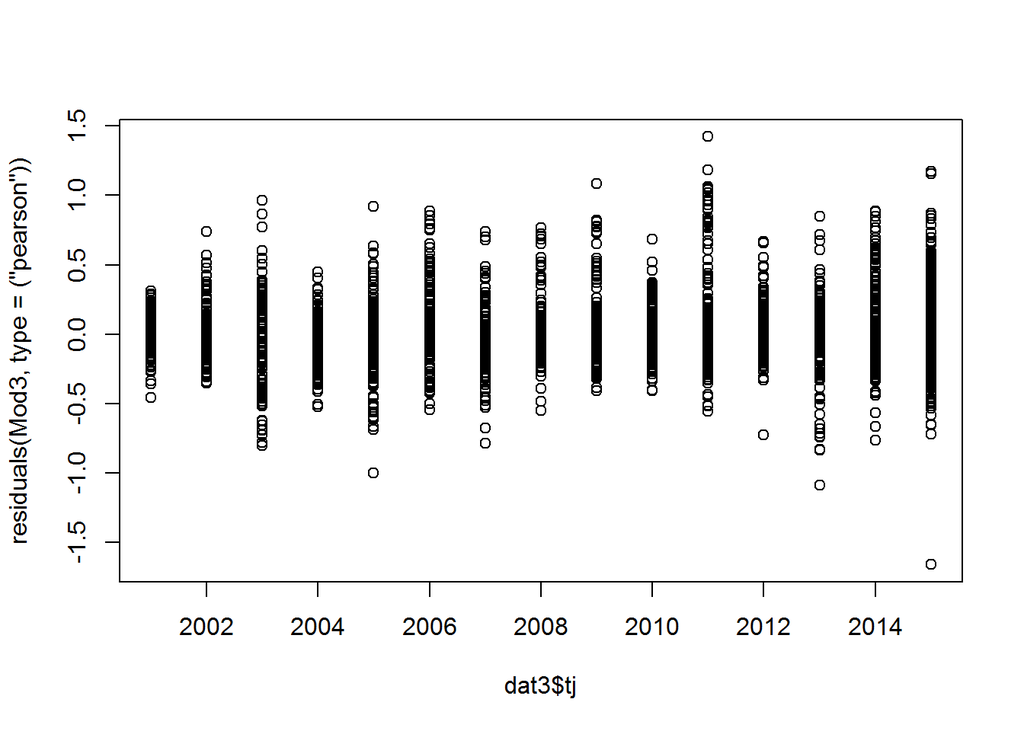

## Model 4

```r
Mod4 <- asreml(fixed   = adjmean ~ ri + tj,
                 random  = ~ G + L + Y +
                           G:L   + sc_ri:G:L   +
                                    c_ri:G:L   +
                           G:Y   + sc_ri:G:Y   + sc_tj:G:Y   +
                                    c_ri:G:Y   +  c_tj:G:Y   +
                           G:Env + sc_ri:G:Env + sc_tj:G:Env +
                                    c_ri:G:Env +  c_tj:G:Env,
                 ran.order = "user",
                 G.param = Gpar,
                 weights = w,
                 family  = asreml.gaussian(dispersion=1.0),
                 control = asreml.control(pworkspace=8e10,workspace=8e8,maxiter=100),
                 data    = dat3)
```

```
## ASReml: Mon Feb 05 09:59:14 2018
##
##      LogLik         S2      DF      wall     cpu
##   -5353.7932      1.0000  2544  09:59:15     0.1 (16 restrained)
##   -5203.2542      1.0000  2544  09:59:15     0.1 (14 restrained)
##   -4307.4374      1.0000  2544  09:59:15     0.1 (1 restrained)
## Logliklihood decreased to   -6000.66 - trying again with reduced updates
## Logliklihood decreased to   -4645.74 - trying again with reduced updates
## Terminating with nfault = 3
##
## Finished on: Mon Feb 05 09:59:15 2018
##
## Convergence failed
```